# ゼミ前統計分析勉強会2018 第1回

Hikaru GOTO

2018年4月28日

## 0．ライブラリの準備

```r
library(tidyverse)
# インストールしていなければ，install.packages("tidyverse")
```

## 1．データのインポート

この操作は右上の「import Dataset」アイコンから可能。

### おまじない

```r
options(scipen=100) # 指数表示を避けるため
```

## 2．Importしたデータをコピーしてオリジナルを保存

この作業は必須ではないですが，私の場合，データをこねくり回しても元に戻せるようにバックアップを取ることが多いです。

```r
d = titanic_data
```

```r
head(d)
```

|  | name | survived | gender | age | passengerClass |
| --- | --- | --- | --- | --- | --- |
| 1 | Allen, Miss. Elisabeth Walton | 1 | female | 29 | 1st |
| 2 | Allison, Master. Hudson Trevor | 1 | male | 0.9 | 1st |
| 3 | Allison, Miss. Helen Loraine | 0 | female | 2 | 1st |
| 4 | Allison, Mr. Hudson Joshua Crei | 0 | male | 30 | 1st |
| 5 | Allison, Mrs. Hudson J C (Bessi | 0 | female | 25 | 1st |
| 6 | Anderson, Mr. Harry | 1 | male | 48 | 1st |
| 7 | Andrews, Miss. Kornelia Theodos | 1 | female | 63 | 1st |
| 8 | Andrews, Mr. Thomas Jr | 0 | male | 39 | 1st |
| 9 | Appleton, Mrs. Edward Dale (Cha | 1 | female | 53 | 1st |
| 10 | Artagaveytia, Mr. Ramon | 0 | male | 71 | 1st |

[output cut: 1299 more lines]

## 3．データの構造を見る

```r
str(d)
```

```
## Classes 'tbl_df', 'tbl' and 'data.frame':    1309 obs. of  5 variables:
##  $ name          : chr  "Allen, Miss. Elisabeth Walton" "Allison, Master. Hudson Trevor" "Allison, Miss. Helen Loraine" "Allison, Mr. Hudson Joshua Crei" ...
##  $ survived      : num  1 1 0 0 0 1 1 0 1 0 ...
##  $ gender        : chr  "female" "male" "female" "male" ...
##  $ age           : chr  "29" "0.9" "2" "30" ...
##  $ passengerClass: chr  "1st" "1st" "1st" "1st" ...
```

## 4．必要な説明変数を因子化などの変換

文字列のデータはそのまま分析できません。そのため数値として扱えるように，因子化します。`age`は数値型に`as.numeric()`を使って変換します。因子化は，`as.factor`もしくは`factor()`関数を使います。

```r
d$gender = as.factor(d$gender)
d$age = as.numeric(d$age)
d$passengerClass = as.factor(d$passengerClass)
```

変換できたか，念のためチェックします。

```r
str(d) # ちゃんと変換できたかチェック
```

```
## Classes 'tbl_df', 'tbl' and 'data.frame':    1309 obs. of  5 variables:
##  $ name          : chr  "Allen, Miss. Elisabeth Walton" "Allison, Master. Hudson Trevor" "Allison, Miss. Helen Loraine" "Allison, Mr. Hudson Joshua Crei" ...
##  $ survived      : num  1 1 0 0 0 1 1 0 1 0 ...
##  $ gender        : Factor w/ 2 levels "female","male": 1 2 1 2 1 2 1 2 1 2 ...
##  $ age           : num  29 0.9 2 30 25 48 63 39 53 71 ...
##  $ passengerClass: Factor w/ 3 levels "1st","2nd","3rd": 1 1 1 1 1 1 1 1 1 1 ...
```

## 5．ロジスティック回帰

あまりいい図ではないですが，少し可視化しておきます。

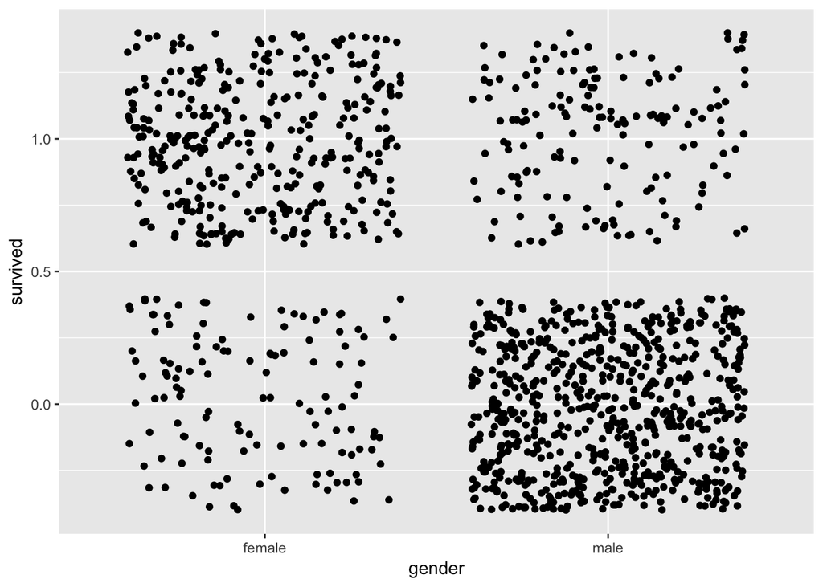

```r
d %>% ggplot(aes(x=gender, y=survived)) + geom_jitter()
```

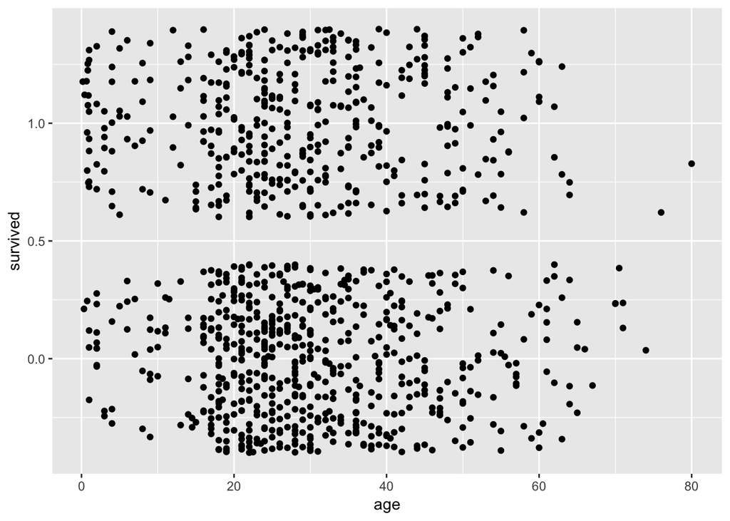

```r
d %>% ggplot(aes(x=age, y=survived)) + geom_jitter()
```

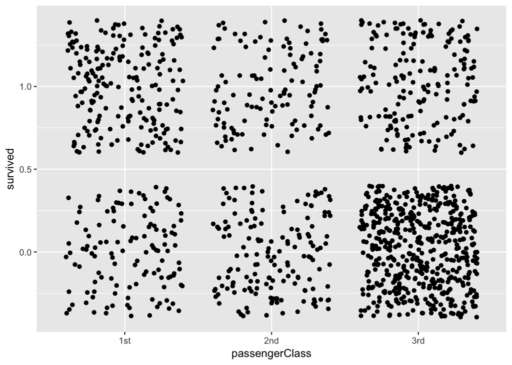

```r
d %>% ggplot(aes(x=passengerClass, y=survived)) + geom_jitter()
```

ロジスティック回帰は`glm()`を使います。分布族に二項分布`family=binomial`を指定するのがポイントです。分析結果を`kekka`というオブジェクトに保存します。名前は好きにつけていいです。

```r
kekka = glm(survived ~ gender + age + passengerClass, data=d, family=binomial)
```

```r
summary(kekka)
```

| term | estimate | std.error | statistic | p.value |
| --- | --- | --- | --- | --- |
| (Intercept) | 3.5220723 | 0.3267013 | 10.780711 | 0.0000000 |
| gendermale | -2.4978455 | 0.1660365 | -15.043954 | 0.0000000 |
| age | -0.0343932 | 0.0063310 | -5.432531 | 0.0000001 |
| passengerClass2nd | -1.2805675 | 0.2255381 | -5.677833 | 0.0000000 |
| passengerClass3rd | -2.2896584 | 0.2258017 | -10.140131 | 0.0000000 |

分析結果が出たところで，オッズ比を確認してみましょう。

## 6．オッズ比を確認

```r
exp(coef(kekka)) #オッズ比
```

|  | x |
| --- | --- |
| (Intercept) | 33.8545126 |
| gendermale | 0.0822620 |
| age | 0.9661915 |
| passengerClass2nd | 0.2778796 |
| passengerClass3rd | 0.1013011 |

```r
exp(confint(kekka)) #オッズ比の95%信頼区間
```

|  | 2.5 % | 97.5 % |
| --- | --- | --- |
| (Intercept) | 18.1147690 | 65.2742374 |
| gendermale | 0.0590684 | 0.1133111 |
| age | 0.9541052 | 0.9781054 |
| passengerClass2nd | 0.1776346 | 0.4303931 |
| passengerClass3rd | 0.0645312 | 0.1565290 |

## 7．もちろん交互作用も検討できる。

```r
kekka_kougo = glm(survived ~ gender + age + passengerClass +
                    gender:age + gender:passengerClass + age:passengerClass,
                    data=d, family=binomial)
```

[output not shown]

```r
exp(coef(kekka_kougo)) # オッズ比
exp(confint(kekka_kougo)) # 95%信頼区間
```

[output not shown]

## 8．別の方法でオッズ比を確認

```r
# install.packages("epiDisplay") # インストールしてなければインストールする
library(epiDisplay) # 使えるようにロードする
logistic.display(kekka) # オッズ比を確認
```

```
##
## Logistic regression predicting survived
##
##                          crude OR(95%CI)   adj. OR(95%CI)
## gender: male vs female   0.08 (0.06,0.11)  0.08 (0.06,0.11)
##
## age (cont. var.)         0.99 (0.98,1)     0.97 (0.95,0.98)
##
## passengerClass: ref.=1st
##    2nd                   0.45 (0.32,0.63)  0.28 (0.18,0.43)
##    3rd                   0.2 (0.15,0.28)   0.1 (0.07,0.16)
##
##                          P(Wald's test) P(LR-test)
## gender: male vs female   < 0.001        < 0.001
##
## age (cont. var.)         < 0.001        < 0.001
##
## passengerClass: ref.=1st                < 0.001
##    2nd                   < 0.001
##    3rd                   < 0.001
##
## Log-likelihood = -491.2264
## No. of observations = 1046
## AIC value = 992.4528
```

### 参考文献

↓はロジスティック回帰オッズ比と信頼区間の出し方を解説されています。

https://researchmap.jp/jomk5xr2p-1781589/

↓はこのHTML文書にある表の作成で参考にしました。

http://yoshi-nishikawa.hatenablog.com/entry/2018/03/21/234347